# Analise Czech

# Objetivo

Um banco quer melhor os seus servicos.

Como exemplo, os gerentes tem apenas uma idéia vaga, de quem é um bom cliente e de quem é o mal cliente.

Os gerentes não possuem nenhum pergunta especifica, então a análise ocorrera com enfoque na exploração, tentando responder algumas hipotéticas questões

- O que, dentro das característoas de um emprestimo, influencia a inadimplencia de um cliente
- A quem deve-se ofertar/reduzir o cartão de acordo com o com região / crédito / perfil do cliente.
- ofertar/reduzir crédito de acordo com região / crédito / perfil do cliente
- marketing para abrir contas em determinada região.

## Analise de inadimplencia do cliente

Um bom cliente, iremos definir que é o cliente que realizar emprestimos e paga os mesmos. Cliente adimplente. Um mal cliente, iremos definir que é o cliente que realizar emprestimos e não paga os mesmos. Cliente inadimplente.

As situações de um emprestimo podem ser:

‘A’ Contrato de emprestimo finalizado sem problema. ‘B’ Contrato de emprestimo finalizado, porém o emprestimo não foi pago. ‘C’ Contrato de emprestimo em andamento, com pagamentos em dia. ‘D’ Contrato de emprestimo em andamento, com pagamentos em atraso.

A pergunta que se quer responder é: Dado um cliente, qual a probabilidade de quando o emprestimo for finalizado, ele se tornar inadimplente ou ter contrato default?

*Podemos também determinar quem é um bom cliente por outros prismas, mas para esta análise iremos focar na relação de cliente e emprestimos.*

# Leitura de dados

O banco possue dados históricos, de transações, emprestimos, geolocalizacao, uso do cartão e outros. Os dados foram limpos e encontram-se em uma base MySQL

Para mais informações sobre o modelo de dados, vide documento **PKDD’99 Discovery Challenge Guide to the Financial Data Set**

Estes dados serão utilizados para a modelagem do problema e construção de um modelo preditivo

# Análise Exploratória

Os empréstimos, possuem a distribuição a seguir:

```r
loan <- dbReadTable(con, "loan")
```

```
Decimal MySQL column 3 imported as numericDecimal MySQL column 6 imported as numeric
```

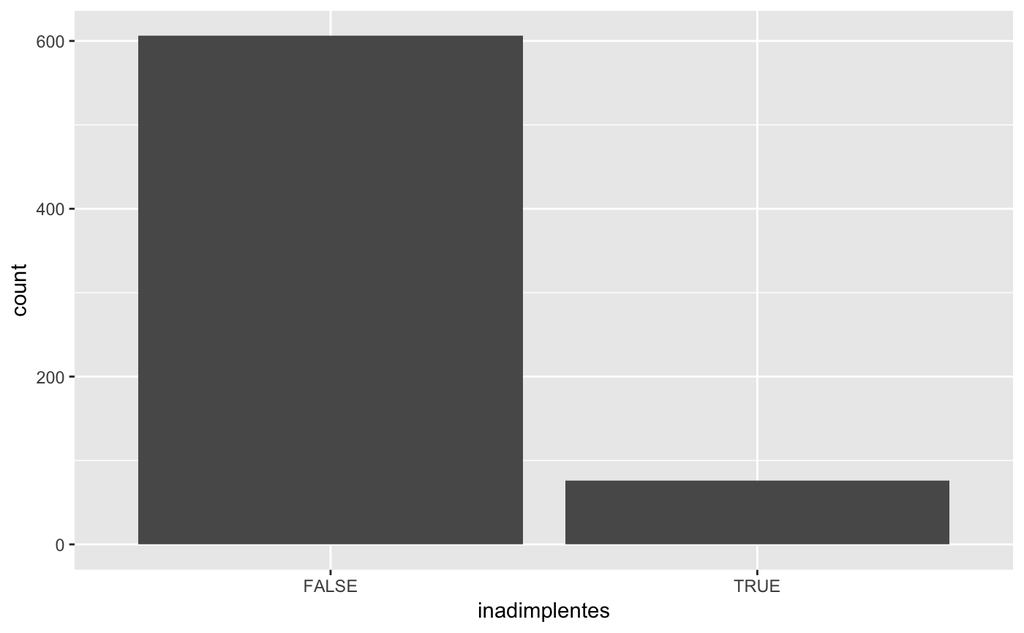

```r
loan <- loan %>% mutate(inadimplentes = (status == "B" | status == "D"))
loan %>% ggplot(aes(x=inadimplentes)) + geom_bar()
```

# Correlações, apenas utilizando variáveis de empréstimo.

## Montante do empréstimo influência?

H0 : O montante do empréstimo não influencia a inadimplência HA : O montante do empréstimo influencia a inadimplência

```r
model_amount <- glm(inadimplentes ~ amount, data = loan)
summary(model_amount)
```

```
Call:
glm(formula = inadimplentes ~ amount, data = loan)

Deviance Residuals:
     Min        1Q    Median        3Q       Max
-0.31590  -0.12891  -0.08565  -0.06161   0.94531

Coefficients:
             Estimate Std. Error t value Pr(>|t|)
(Intercept) 4.098e-02  1.986e-02   2.064   0.0394 *
amount      4.653e-07  1.050e-07   4.431 1.09e-05 ***
---
Signif. codes:  0 ‘***’ 0.001 ‘**’ 0.01 ‘*’ 0.05 ‘.’ 0.1 ‘ ’ 1

(Dispersion parameter for gaussian family taken to be 0.09652288)

    Null deviance: 67.531  on 681  degrees of freedom
Residual deviance: 65.636  on 680  degrees of freedom
AIC: 344.93

Number of Fisher Scoring iterations: 2
```

```r
melhor_modelo <- model_amount
```

## A duraçãoo dos emprestimos

- H0 : A duração dos empréstimos não influência a inadimplencia
- HA : A duração dos empréstimos influência a inadimplencia

```r
model_duration <- glm(inadimplentes ~ durantion, data = loan)
summary(model_duration)
```

```
Call:
glm(formula = inadimplentes ~ durantion, data = loan)

Deviance Residuals:
     Min        1Q    Median        3Q       Max
-0.12263  -0.11692  -0.11120  -0.09977   0.90023

Coefficients:
             Estimate Std. Error t value Pr(>|t|)
(Intercept) 0.0940581  0.0284807   3.303  0.00101 **
durantion   0.0004762  0.0007070   0.674  0.50079
---
Signif. codes:  0 ‘***’ 0.001 ‘**’ 0.01 ‘*’ 0.05 ‘.’ 0.1 ‘ ’ 1

(Dispersion parameter for gaussian family taken to be 0.09924377)

    Null deviance: 67.531  on 681  degrees of freedom
Residual deviance: 67.486  on 680  degrees of freedom
AIC: 363.89

Number of Fisher Scoring iterations: 2
```

## E ambos juntos?

```r
novo_modelo <- glm(inadimplentes ~ durantion + amount, data = loan)
summary(novo_modelo)
```

```
Call:
glm(formula = inadimplentes ~ durantion + amount, data = loan)

Deviance Residuals:
     Min        1Q    Median        3Q       Max
-0.35446  -0.12959  -0.09310  -0.05778   0.97400

Coefficients:
              Estimate Std. Error t value Pr(>|t|)
(Intercept)  9.202e-02  2.797e-02   3.289  0.00106 **
durantion   -2.265e-03  8.783e-04  -2.579  0.01011 *
amount       6.743e-07  1.323e-07   5.097 4.48e-07 ***
---
Signif. codes:  0 ‘***’ 0.001 ‘**’ 0.01 ‘*’ 0.05 ‘.’ 0.1 ‘ ’ 1

(Dispersion parameter for gaussian family taken to be 0.09572713)

    Null deviance: 67.531  on 681  degrees of freedom
Residual deviance: 64.999  on 679  degrees of freedom
AIC: 340.28

Number of Fisher Scoring iterations: 2
```

```r
melhor_modelo <- novo_modelo
```

O valor e a duração juntos influenciam a inadimplencia!

## O valor das parcelas influenciam?

H0 : O valor das parcelas não influência a inadimplencia HA : O valor das parcelas influência a inadimplencia

```r
novo_modelo <- glm(inadimplentes ~ payments, data = loan)
summary(novo_modelo)
```

[output not shown]

Mas devemos incluir a valor no modelo candidato ?

```r
novo_modelo <- glm(inadimplentes ~ amount + durantion + payments, data = loan)
summary(novo_modelo)
```

[output not shown]

## O Sexo do cliente influencia na inadimplencia?

O sexo entre os clientes se distribui como

```r
account_client %>% ggplot(aes(x=sex)) + geom_bar()
```

[output not shown]

```r
account_loan <- account_client %>% merge(loan, by = "account_id")
novo_modelo <- glm(inadimplentes ~ sex , data = account_loan)
summary(novo_modelo)
```

[output not shown]

## A idade do cliente influencia na inadimplencia?